# SOLUTIONS: Homework/Problem Set 1

Statistical Analysis of Networks (CRJ) 605

```r
# load libraries.
library(sna, quietly = TRUE)
library(network, quietly = TRUE)
library(RColorBrewer)

# clear the workspace.
rm(list = ls())
```

# **Problems**

### **For *each* network (i.e. `talk.course.net` and `trust.net`) do the following**:

1. Import the network into *R* and create an object of class `network`.
2. Plot the network using the `gplot()` function.
3. Modify the plot using at least three arguments in the `gplot()` function.
4. Calculate the indegree and outdegree for each actor.
5. Calculate the standardized indegree and outdegree for each actor.
6. Calculate the mean indegree and outdegree.
7. Compare the two means.
8. Calcuate the graph centralization for indegree and outdegree.
9. Compare the two graph centralization scores.

# **Solutions**

### **Analysis of Talked about the Course network**:

1. Import the network into *R* and create an object of class `network`.

```r
# read in the data.
talk.adj.mat <- read.csv(
  url("https://www.jacobtnyoung.com/uploads/2/3/4/5/23459640/crj_605_networks_spring_2019_talk_course_w1_adjancency.csv"), # pull from the website.
  as.is=TRUE, row.names = 1, header = TRUE #set up the arguments to read it in correctly.
)
dim(talk.adj.mat) # check dimensions.
```

```
## [1] 15 15
```

```r
talk.net <- as.network(talk.adj.mat, directed = TRUE) # create the network object.
summary(talk.net, print.adj = FALSE) # take a look at the data.
```

```
## Network attributes:
##   vertices = 15
##   directed = TRUE
##   hyper = FALSE
##   loops = FALSE
##   multiple = FALSE
##   bipartite = FALSE
##  total edges = 59
##    missing edges = 0
##    non-missing edges = 59
##  density = 0.2809524
##
## Vertex attributes:
##   vertex.names:
##    character valued attribute
##    15 valid vertex names
##
## No edge attributes
```

2. Plot the network using the `gplot()` function.

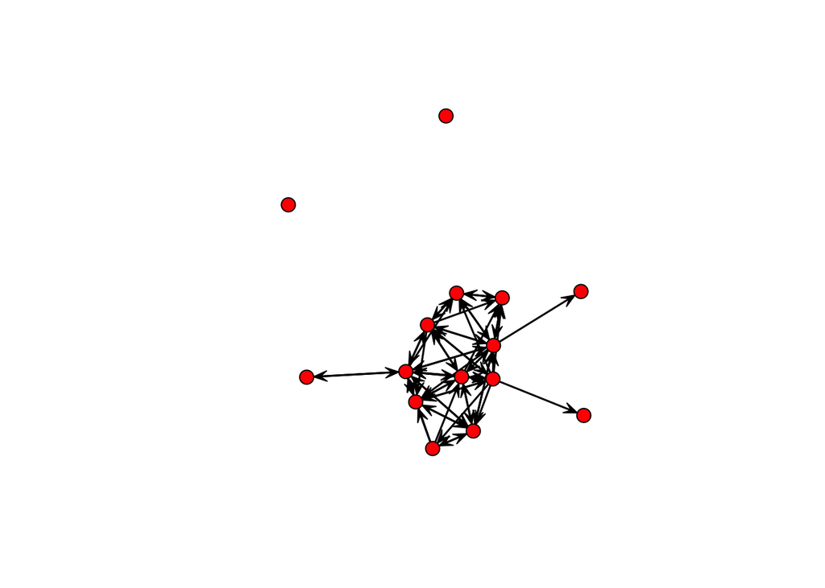

```r
gplot(talk.net)
```

3. Modify the plot using at least three arguments in the `gplot()` function.

```r
# for this, let's load the data file that has the attributes.
load(url("https://www.jacobtnyoung.com/uploads/2/3/4/5/23459640/crj_605_networks_spring_2019_class_survey_data_w1.rdata"))
ls() # check out the workspace objects.
```

```
## [1] "class.data.w1"   "spend.time.net"  "talk.adj.mat"    "talk.course.net"
## [5] "talk.net"        "trust.net"
```

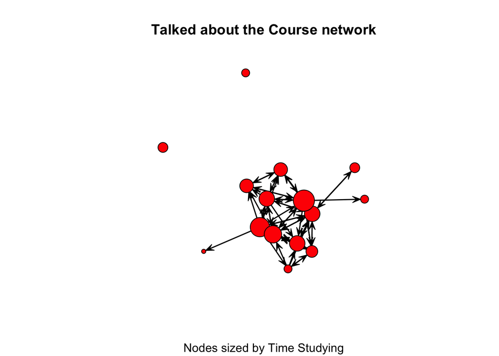

```r
# Then, let's create the rescale function that we will use.
rescale <- function(nchar,low,high){
  min_d <- min(nchar)
  max_d <- max(nchar)
  rscl  <- ((high-low)*(nchar-min_d)) / (max_d-min_d)+low
  rscl
}

# First modification: size nodes based on time studying.
gplot(talk.net,vertex.cex=rescale(class.data.w1$"Studyt1",0.5,2.5), main="Talked about the Course network",sub="Nodes sized by Time Studying")
```

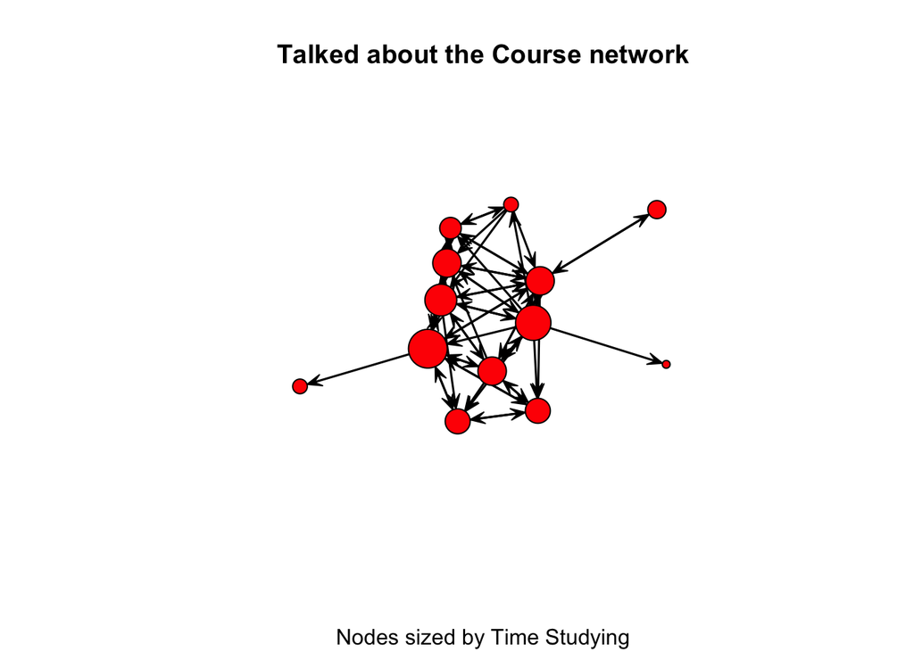

```r
# Second modification: remove isolates.
gplot(talk.net,vertex.cex=rescale(class.data.w1$"Studyt1",0.5,2.5),displayisolates = FALSE, main="Talked about the Course network",sub="Nodes sized by Time Studying")
```

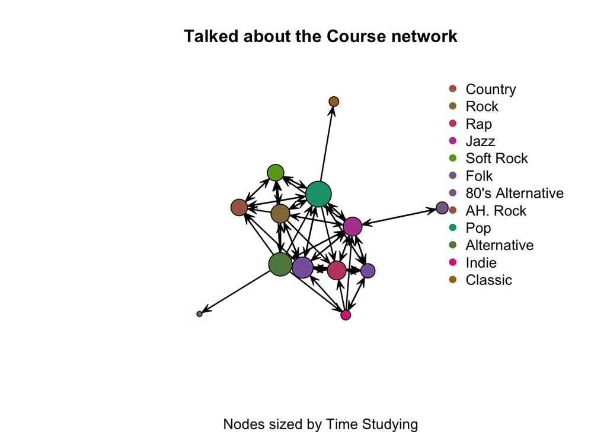

```r
# Third modification: color nodes based on music genre.
col.music   <- colorRampPalette(brewer.pal(5, "Dark2"))(length(unique(class.data.w1$"Musict1")))
col.music   <- col.music[as.factor(class.data.w1$"Musict1")]
set.seed(1)
gplot(talk.net,vertex.cex=rescale(class.data.w1$"Studyt1",0.5,2.5),displayisolates = FALSE,vertex.col = col.music, main="Talked about the Course network",sub="Nodes sized by Time Studying")
legend("topright",legend=as.factor(unique(class.data.w1$"Musict1")),col=col.music,pch=19,bty="n")
```

4. Calculate the indegree and outdegree for each actor.

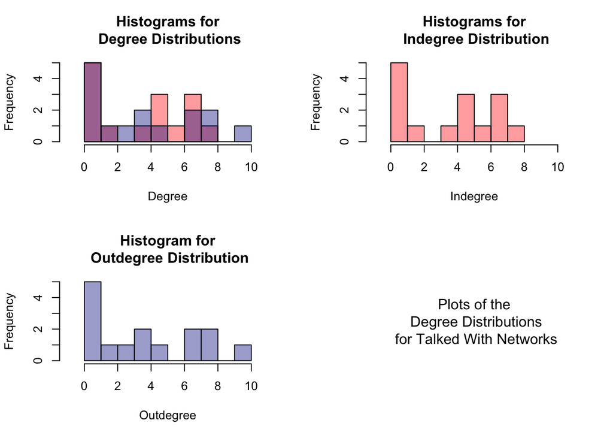

```r
# use the degree() function in the sna package.
library(sna)
ideg.talk <- degree(talk.net,gmode = "digraph", cmode = "indegree")
odeg.talk <- degree(talk.net,gmode = "digraph", cmode = "outdegree")

# take a look at the distributions.
deg.data  <- c(ideg.talk,odeg.talk)
par(mfrow=c(2,2))
hist(ideg.talk,col=rgb(255,0,0,alpha=100,maxColorValue = 255),xlim=c(min(deg.data)-1,max(deg.data)+1),xlab="Degree",main="Histograms for\n Degree Distributions",breaks=10)
hist(odeg.talk,col=rgb(0,0,139,alpha=100,maxColorValue = 255),add=TRUE,breaks=10)
hist(ideg.talk,col=rgb(255,0,0,alpha=100,maxColorValue = 255),xlim=c(min(deg.data)-1,max(deg.data)+1),xlab="Indegree",main="Histograms for\n Indegree Distribution",breaks=10)
hist(odeg.talk,col=rgb(0,0,139,alpha=100,maxColorValue = 255),xlim=c(min(deg.data)-1,max(deg.data)+1),xlab="Outdegree",main="Histogram for\n Outdegree Distribution",breaks=10)
plot(c(0, 1), c(0, 1), ann = F, bty = 'n', type = 'n', xaxt = 'n', yaxt = 'n')
text(x = 0.5, y = 0.5, paste("Plots of the\n Degree Distributions\n for Talked With Networks"),cex = 1.2, col = "black")
```

```r
par(mfrow=c(1,1))
```

5. Calculate the standardized indegree and outdegree for each actor.

```r
# standardized score is deg / g-1 where g is the number of nodes.
s.ideg.talk <- ideg.talk / (dim(as.matrix(talk.net))[1]-1)
s.odeg.talk <- odeg.talk / (dim(as.matrix(talk.net))[1]-1)
```

6. Calculate the mean indegree and outdegree.

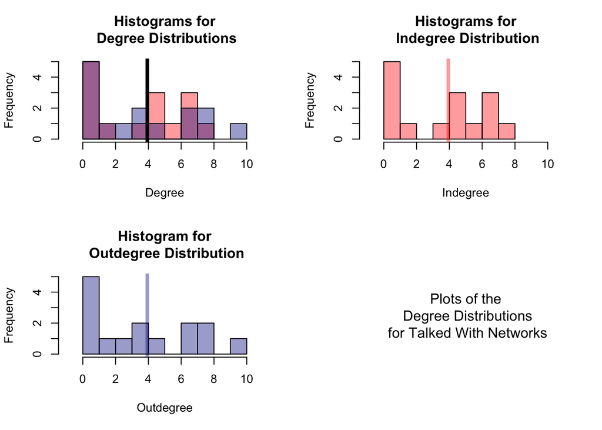

```r
# the mean is L/g for a directed graph where L is the number of edges and g is the number of nodes.
mean.ideg.talk <- sum(as.matrix(talk.net)) / dim(as.matrix(talk.net))[1]
mean.odeg.talk <- sum(as.matrix(talk.net)) / dim(as.matrix(talk.net))[1]

# Now, let's add these to our plots to help visualize the central tendency.
par(mfrow=c(2,2))
hist(ideg.talk,col=rgb(255,0,0,alpha=100,maxColorValue = 255),xlim=c(min(deg.data)-1,max(deg.data)+1),xlab="Degree",main="Histograms for\n Degree Distributions",breaks=10)
hist(odeg.talk,col=rgb(0,0,139,alpha=100,maxColorValue = 255),add=TRUE,breaks=10)
abline(v=mean.odeg.talk,col="black",lwd=4)
hist(ideg.talk,col=rgb(255,0,0,alpha=100,maxColorValue = 255),xlim=c(min(deg.data)-1,max(deg.data)+1),xlab="Indegree",main="Histograms for\n Indegree Distribution",breaks=10)
abline(v=mean.ideg.talk,col=rgb(255,0,0,alpha=100,maxColorValue = 255),lwd=4)
hist(odeg.talk,col=rgb(0,0,139,alpha=100,maxColorValue = 255),xlim=c(min(deg.data)-1,max(deg.data)+1),xlab="Outdegree",main="Histogram for\n Outdegree Distribution",breaks=10)
abline(v=mean.odeg.talk,col=rgb(0,0,139,alpha=100,maxColorValue = 255),lwd=4)
plot(c(0, 1), c(0, 1), ann = F, bty = 'n', type = 'n', xaxt = 'n', yaxt = 'n')
text(x = 0.5, y = 0.5, paste("Plots of the\n Degree Distributions\n for Talked With Networks"),cex = 1.2, col = "black")
```

```r
par(mfrow=c(1,1))
```

7. Compare the two means.

```r
# The means are equal. The average degree is almost 4.
mean.ideg.talk
```

```
## [1] 3.933333
```

```r
mean.odeg.talk
```

```
## [1] 3.933333
```

The means are equal. This is becuse the number of edges does not change when examining the indegree vs. the outdegree.

8. Calcuate the graph centralization for indegree and outdegree.

```r
icent.talk <- centralization(talk.net, degree, mode="digraph", cmode="indegree")
ocent.talk <- centralization(talk.net, degree, mode="digraph", cmode="outdegree")
icent.talk
```

```
## [1] 0.3112245
```

```r
ocent.talk
```

```
## [1] 0.4642857
```

9. Compare the two graph centralization scores.

```r
icent.talk
```

```
## [1] 0.3112245
```

```r
ocent.talk
```

```
## [1] 0.4642857
```

The outdegree centralization score is greater than the indegree centralization score. This means that there is more variation in the outdegree distribution.

### **Analysis of Trust network**:

1. Import the network into *R* and create an object of class `network`.

```r
# read in the data.
trust.adj.mat <- read.csv(
  url("https://www.jacobtnyoung.com/uploads/2/3/4/5/23459640/crj_605_networks_spring_2019_trust_w1_adjancency.csv"), # pull from the website.
  as.is=TRUE, row.names = 1, header = TRUE #set up the arguments to read it in correctly.
)
dim(trust.adj.mat) # check dimensions.
```

```
## [1] 15 15
```

```r
trust.net <- as.network(trust.adj.mat, directed = TRUE) # create the network object.
summary(trust.net, print.adj = FALSE) # take a look at the data.
```

```
## Network attributes:
##   vertices = 15
##   directed = TRUE
##   hyper = FALSE
##   loops = FALSE
##   multiple = FALSE
##   bipartite = FALSE
##  total edges = 38
##    missing edges = 0
##    non-missing edges = 38
##  density = 0.1809524
##
## Vertex attributes:
##   vertex.names:
##    character valued attribute
##    15 valid vertex names
##
## No edge attributes
```

2. Plot the network using the `gplot()` function.

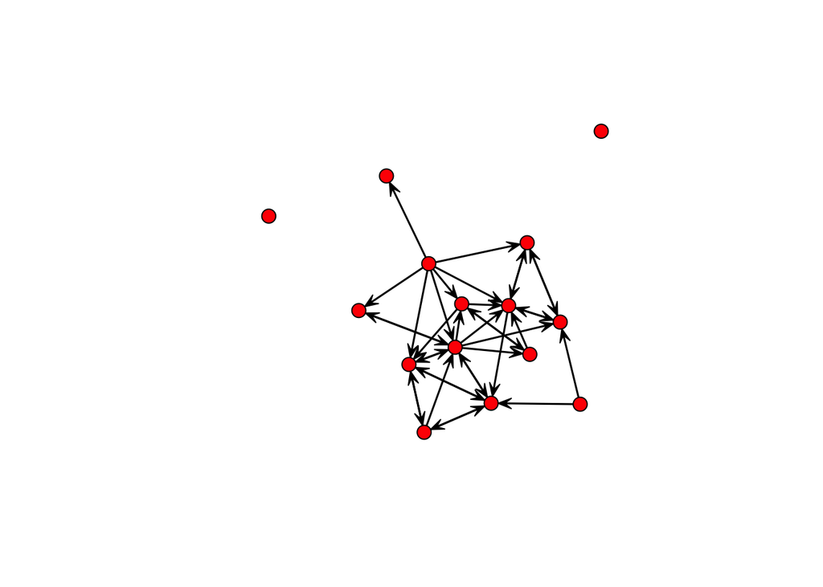

```r
gplot(trust.net)
```

3. Modify the plot using at least three arguments in the `gplot()` function.

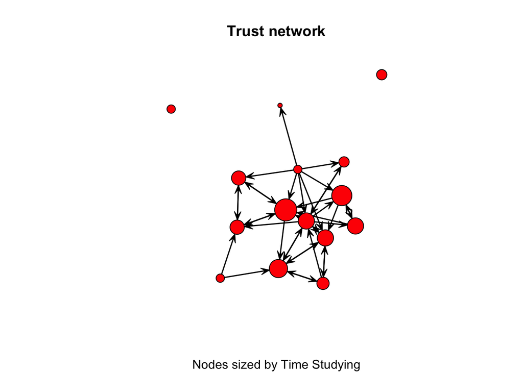

```r
# for this, let's load the data file that has the attributes.
load(url("https://www.jacobtnyoung.com/uploads/2/3/4/5/23459640/crj_605_networks_spring_2019_class_survey_data_w1.rdata"))

# Then, let's create the rescale function that we will use.
rescale <- function(nchar,low,high){
  min_d <- min(nchar)
  max_d <- max(nchar)
  rscl  <- ((high-low)*(nchar-min_d)) / (max_d-min_d)+low
  rscl
}

# First modification: size nodes based on time studying.
gplot(trust.net,vertex.cex=rescale(class.data.w1$"Studyt1",0.5,2.5), main="Trust network",sub="Nodes sized by Time Studying")
```

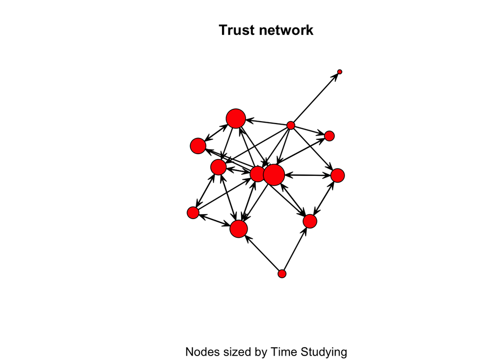

```r
# Second modification: remove isolates.
gplot(trust.net,vertex.cex=rescale(class.data.w1$"Studyt1",0.5,2.5),displayisolates = FALSE, main="Trust network",sub="Nodes sized by Time Studying")
```

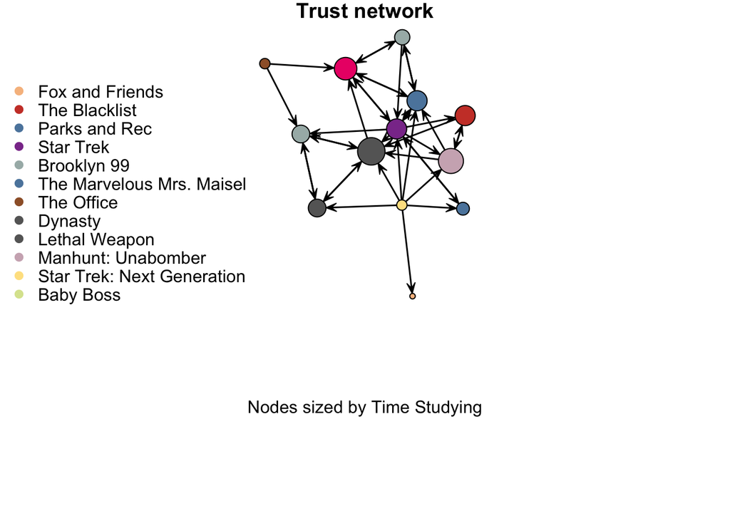

```r
# Third modification: color nodes based on TV Show.
col.music   <- colorRampPalette(brewer.pal(8, "Accent"))(length(unique(class.data.w1$"TV1t1")))
col.music   <- col.music[as.factor(class.data.w1$"TV1t1")]
op <- par(mar = c(10,0,1,0))
set.seed(1)
gplot(trust.net,vertex.cex=rescale(class.data.w1$"Studyt1",0.5,2.5),displayisolates = FALSE,vertex.col = col.music, main="Trust network",sub="Nodes sized by Time Studying")
par(op)
legend("bottomleft",legend=as.factor(unique(class.data.w1$"TV1t1")),col=col.music,pch=19,bty="n")
```

4. Calculate the indegree and outdegree for each actor.

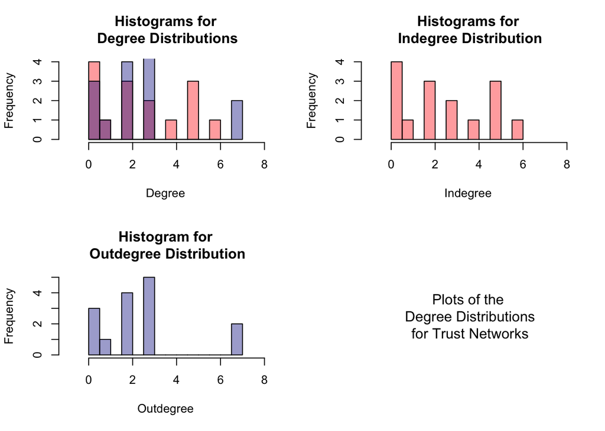

```r
ideg.trust <- degree(trust.net, gmode = "digraph", cmode = "indegree")
odeg.trust <- degree(trust.net, gmode = "digraph", cmode = "outdegree")

# take a look at the distributions.
deg.data  <- c(ideg.trust,odeg.trust)
par(mfrow=c(2,2))
hist(ideg.trust,col=rgb(255,0,0,alpha=100,maxColorValue = 255),xlim=c(min(deg.data)-1,max(deg.data)+1),xlab="Degree",main="Histograms for\n Degree Distributions",breaks=10)
hist(odeg.trust,col=rgb(0,0,139,alpha=100,maxColorValue = 255),add=TRUE,breaks=10)
hist(ideg.trust,col=rgb(255,0,0,alpha=100,maxColorValue = 255),xlim=c(min(deg.data)-1,max(deg.data)+1),xlab="Indegree",main="Histograms for\n Indegree Distribution",breaks=10)
hist(odeg.trust,col=rgb(0,0,139,alpha=100,maxColorValue = 255),xlim=c(min(deg.data)-1,max(deg.data)+1),xlab="Outdegree",main="Histogram for\n Outdegree Distribution",breaks=10)
plot(c(0, 1), c(0, 1), ann = F, bty = 'n', type = 'n', xaxt = 'n', yaxt = 'n')
text(x = 0.5, y = 0.5, paste("Plots of the\n Degree Distributions\n for Trust Networks"),cex = 1.2, col = "black")
```

```r
par(mfrow=c(1,1))
```

5. Calculate the standardized indegree and outdegree for each actor.

```r
# standardized score is deg / g-1 where g is the number of nodes.
s.ideg.trust <- ideg.trust / (dim(as.matrix(trust.net))[1]-1)
s.odeg.trust <- odeg.trust / (dim(as.matrix(trust.net))[1]-1)
s.ideg.trust
```

```
##  [1] 0.07142857 0.14285714 0.35714286 0.35714286 0.28571429 0.14285714
##  [7] 0.00000000 0.21428571 0.42857143 0.21428571 0.00000000 0.00000000
## [13] 0.35714286 0.14285714 0.00000000
```

```r
s.odeg.trust
```

```
##  [1] 0.00000000 0.14285714 0.21428571 0.50000000 0.14285714 0.07142857
##  [7] 0.14285714 0.14285714 0.21428571 0.21428571 0.50000000 0.00000000
## [13] 0.21428571 0.21428571 0.00000000
```

6. Calculate the mean indegree and outdegree.

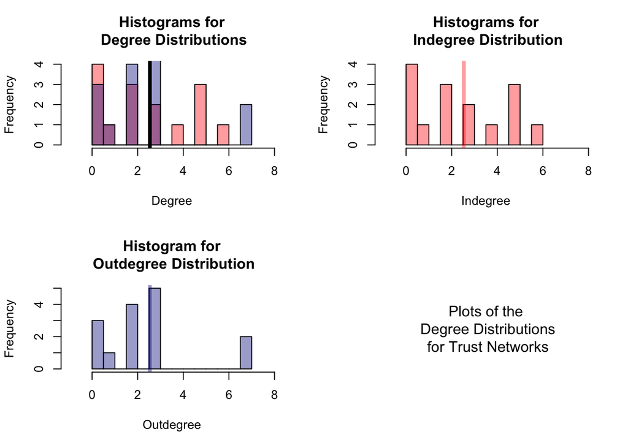

```r
# the mean is L/g for a directed graph where L is the number of edges and g is the number of nodes.
mean.ideg.trust <- sum(as.matrix(trust.net)) / dim(as.matrix(trust.net))[1]
mean.odeg.trust <- sum(as.matrix(trust.net)) / dim(as.matrix(trust.net))[1]

# Now, let's add these to our plots to help visualize the central tendency.
par(mfrow=c(2,2))
hist(ideg.trust,col=rgb(255,0,0,alpha=100,maxColorValue = 255),xlim=c(min(deg.data)-1,max(deg.data)+1),xlab="Degree",main="Histograms for\n Degree Distributions",breaks=10)
hist(odeg.trust,col=rgb(0,0,139,alpha=100,maxColorValue = 255),add=TRUE,breaks=10)
abline(v=mean.odeg.trust,col="black",lwd=4)
hist(ideg.trust,col=rgb(255,0,0,alpha=100,maxColorValue = 255),xlim=c(min(deg.data)-1,max(deg.data)+1),xlab="Indegree",main="Histograms for\n Indegree Distribution",breaks=10)
abline(v=mean.ideg.trust,col=rgb(255,0,0,alpha=100,maxColorValue = 255),lwd=4)
hist(odeg.trust,col=rgb(0,0,139,alpha=100,maxColorValue = 255),xlim=c(min(deg.data)-1,max(deg.data)+1),xlab="Outdegree",main="Histogram for\n Outdegree Distribution",breaks=10)
abline(v=mean.odeg.trust,col=rgb(0,0,139,alpha=100,maxColorValue = 255),lwd=4)
plot(c(0, 1), c(0, 1), ann = F, bty = 'n', type = 'n', xaxt = 'n', yaxt = 'n')
text(x = 0.5, y = 0.5, paste("Plots of the\n Degree Distributions\n for Trust Networks"),cex = 1.2, col = "black")
```

```r
par(mfrow=c(1,1))
```

7. Compare the two means.

```r
# The means are equal. The average degree is almost 3.
mean.ideg.trust
```

```
## [1] 2.533333
```

```r
mean.odeg.trust
```

```
## [1] 2.533333
```

The means are equal. This is becuse the number of edges does not change when examining the indegree vs. the outdegree.

8. Calcuate the graph centralization for indegree and outdegree.

```r
icent.trust <- centralization(trust.net, degree, mode="digraph", cmode="indegree")
ocent.trust <- centralization(trust.net, degree, mode="digraph", cmode="outdegree")
```

9. Compare the two graph centralization scores.

```r
icent.trust
```

```
## [1] 0.2653061
```

```r
ocent.trust
```

```
## [1] 0.3418367
```

The outdegree centralization score is greater than the indegree centralization score. This means that there is more variation in the outdegree distribution.

### **Comparison of the networks**:

10. How are the indegree and outdegree different for these networks?
11. What do the differences in the graph centralization scores for these networks tell us?

For most comparisons, we need to examine the *standardized* degree centrality measures. But, because the number of nodes is equal across the networks, the unstandarized measures will tell us the same information.

First, let’s compare the indegree distributions. We can do this by examining the summary statistics we created. Specifically, the *mean* and the *centralization* of the networks:

```r
mean.ideg.talk
```

```
## [1] 3.933333
```

```r
mean.ideg.trust
```

```
## [1] 2.533333
```

We can see that the mean indegree for the talk network is *greater* than the mean degree for the trust network. This indicates that individuals, on average, are more likely to receive a **talked with** nomination relative to a **trust** nomination.

We can further examine the differences by comparing the centralization scores:

```r
icent.talk
```

```
## [1] 0.3112245
```

```r
icent.trust
```

```
## [1] 0.2653061
```

The differences indicate that the talk network shows greater centralization than the trust network. In other words, the nodes in the trust network have less variation in their indegree.

### **BONUS Question**:

12. For the `trust.net` network, are people who trust others *more* or *less* likely to be trusted?

This is just the correlation between the indegree and the outdegree:

```r
cor(ideg.trust,odeg.trust)
```

```
## [1] 0.346484
```

The correlation is 0.35, indicating that those who trust others more (i.e. send more ties), are more likely to be trusted (i.e. receive more ties).